# HW4

Anish Mohan

February 7, 2017

# Summary

# Q1: Testing Normality

#### Q1:Compare and test Normality the distributions of price and log price.Use both a graphical method and a formal test.

#### Testing the normality of the data with Q-Q Plot

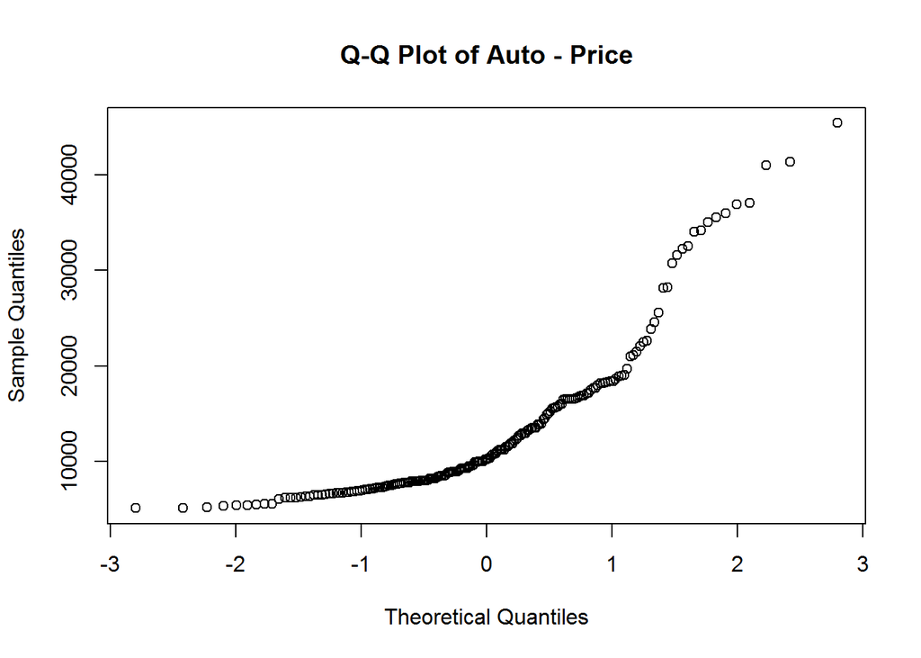

```r
# Normality of Price (In Automobile):
auto.price = auto$price
auto.log.price = log(auto$price)
qqnorm(auto.price, main = "Q-Q Plot of Auto - Price")
```

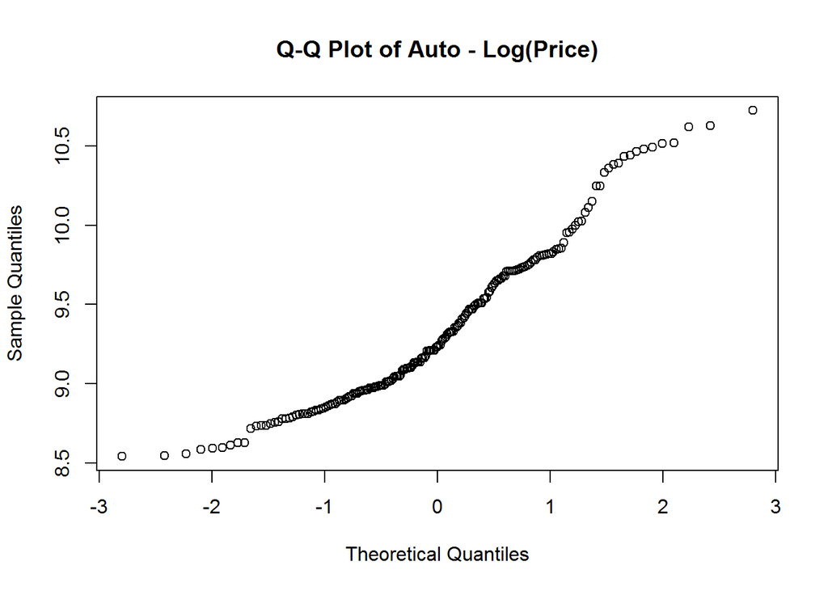

```r
qqnorm(auto.log.price, main = "Q-Q Plot of Auto - Log(Price)")
```

A Visual inspection of the Q-Q Plot shows that the points of log(price) are closer to a straight line compared to price of the Autos.

#### K-S Test for normality

```r
norm1 = rnorm(200,mean=0,sd=1)

# KS Test for normality

#Scaling and Centring variable for the K-S Test
auto.log.price.scaled = scale(auto.log.price, center = TRUE, scale = TRUE)
auto.price.scaled = scale(auto.price, center = TRUE, scale = TRUE)
summary(auto.log.price.scaled)
```

```
##        V1
##  Min.   :-1.5802
##  1st Qu.:-0.7552
##  Median :-0.2464
##  Mean   : 0.0000
##  3rd Qu.: 0.8074
##  Max.   : 2.7695
```

```r
summary(auto.price.scaled)
```

```
##        V1
##  Min.   :-1.0765
##  1st Qu.:-0.6931
##  Median :-0.3765
##  Mean   : 0.0000
##  3rd Qu.: 0.5570
##  Max.   : 4.0168
```

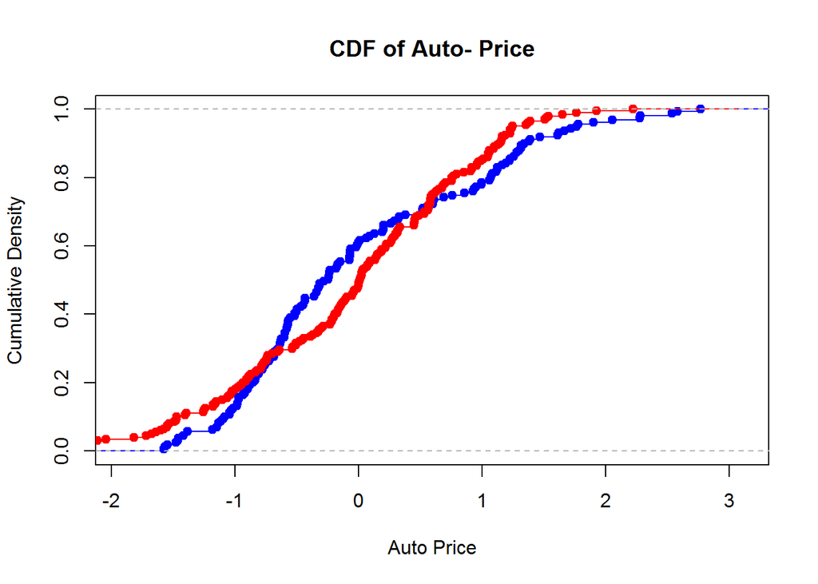

```r
#Plotting CDF Curve
plot(ecdf(auto.log.price.scaled), col = "blue", main = "CDF of Auto- Price", xlab = "Auto Price", ylab = "Cumulative Density")
lines(ecdf(norm1), col = "red")
```

#### Calculating K-S Statistics

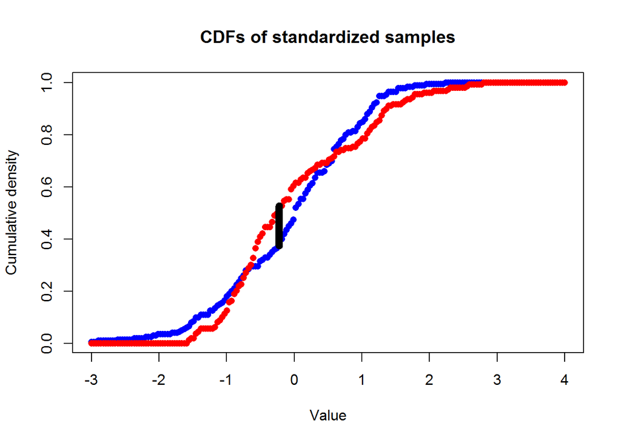

```r
# Defining x variables.
x_seq = seq(-3,4,len=200)

# Building the CDF for the Normally Distributed Variable.
norm.cdf = sapply(x_seq, function(x){
  sum(norm1<x)/length(norm1)
})

# Building the CDF for log(Price) of the Auto.
log.price.cdf = sapply(x_seq, function(x){
  sum(auto.log.price.scaled<x)/length(auto.log.price.scaled)
})

# Building the CDF for Price of the Auto
price.cdf = sapply(x_seq, function(x){
  sum(auto.price.scaled<x)/length(auto.price.scaled)
})

# Calculating K-S Statistic
k_s_stat = max(abs(norm.cdf - log.price.cdf))

# Location of the max value
k_index = which.max(abs(norm.cdf - log.price.cdf))

k_s_x = x_seq[k_index]
plot(x_seq,norm.cdf, col='blue', pch=16, main ='CDFs of standardized samples',
     xlab = 'Value', ylab = 'Cumulative density')
points(x_seq,log.price.cdf,col='red', pch=16)
lines(c(k_s_x,k_s_x), c(norm.cdf[k_index],log.price.cdf[k_index]),
      col='black', lwd=8)
```

```r
#Printing K-S Value
print(paste0("Comparing Normal CDF and Log Price CDF: K-S=", k_s_stat))
```

```
## [1] "Comparing Normal CDF and Log Price CDF: K-S=0.153301886792453"
```

```r
print(paste0("Empirical P-Value =", k_s_stat/1000))
```

```
## [1] "Empirical P-Value =0.000153301886792453"
```

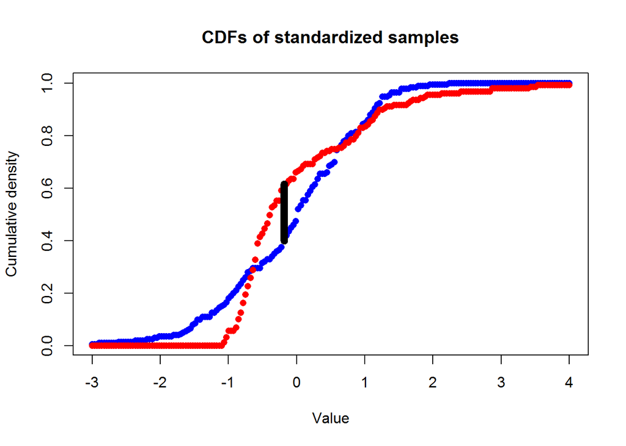

```r
k_s_stat = max(abs(norm.cdf - price.cdf))

# where does it occur?
k_index = which.max(abs(norm.cdf - price.cdf))
k_s_x = x_seq[k_index]
plot(x_seq, norm.cdf, col='blue', pch=16, main ='CDFs of standardized samples',
     xlab = 'Value', ylab = 'Cumulative density')
points(x_seq,price.cdf,col='red', pch=16)
lines(c(k_s_x,k_s_x), c(norm.cdf[k_index],price.cdf[k_index]),
      col='black', lwd=8)
```

```r
print(paste0("Comparing Normal CDF and Auto Price CDF: K-S=", k_s_stat))
```

```
## [1] "Comparing Normal CDF and Auto Price CDF: K-S=0.216352201257862"
```

```r
print(paste0("Empirical P-Value =", k_s_stat/1000))
```

```
## [1] "Empirical P-Value =0.000216352201257862"
```

K-S Statistic also shows there is lower deviation between a std normal distribution and Log(Auto Price) compared to Std Normal distribution and Auto Price.

## Q2 Testing Significance stratified with variables

#### Test significance of price (log price) stratified by a) fuel type, b) aspiration, and c) rear vs. front wheel drive. Use both graphical methods and the formal test.

```r
# Plotting fuction for histogram of distributions
plot.t <- function(a, b, cols = c('pop_A', 'pop_B'), nbins = 20){
  maxs = max(c(max(a), max(b)))
  mins = min(c(min(a), min(b)))
  breaks = seq(maxs, mins, length.out = (nbins + 1))
  par(mfrow = c(2, 1))
  hist(a, breaks = breaks, main = paste('Histogram of', cols[1]), xlab = cols[1])
  abline(v = mean(a), lwd = 4, col = 'red')
  hist(b, breaks = breaks, main = paste('Histogram of', cols[2]), xlab = cols[2])
  abline(v = mean(b), lwd = 4, col = 'red')
  par(mfrow = c(1, 1))
}
```

#### Histogram comparing prices of different Fuel Type

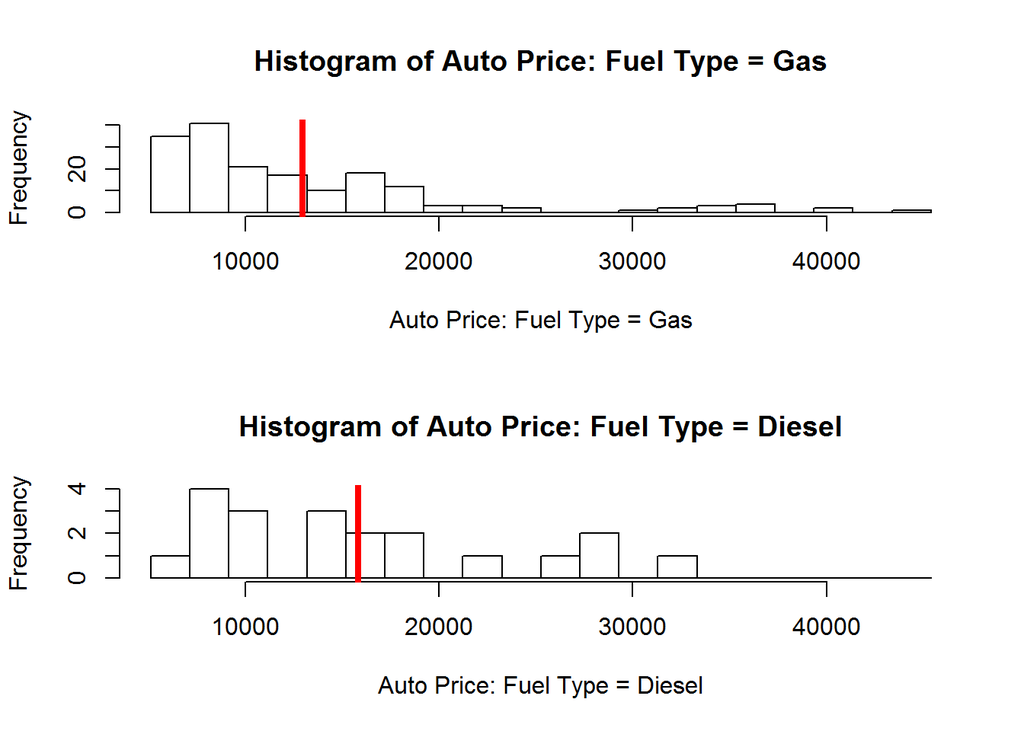

```r
auto.gas.price = auto[auto$fuel.type=="gas",]$price
auto.diesel.price = auto[auto$fuel.type == "diesel",]$price

plot.t(auto.gas.price, auto.diesel.price, cols = c("Auto Price: Fuel Type = Gas","Auto Price: Fuel Type = Diesel"))
```

The histogram shows that there is large standard deviation in the Auto prices. The mean price of the Auto of fuel.type = gas and fuel.type = diesel seem to be close.

#### Student-t test measuring the difference in mean values of prices based on fuel type

```r
t.test(auto.gas.price, auto.diesel.price, alternative = "two.sided")
```

```
##
##  Welch Two Sample t-test
##
## data:  auto.gas.price and auto.diesel.price
## t = -1.5694, df = 23.932, p-value = 0.1297
## alternative hypothesis: true difference in means is not equal to 0
## 95 percent confidence interval:
##  -6682.1579   909.8579
## sample estimates:
## mean of x mean of y
##  12952.00  15838.15
```

#### Student-t test measuring the difference in mean values of prices based on Aspiration type

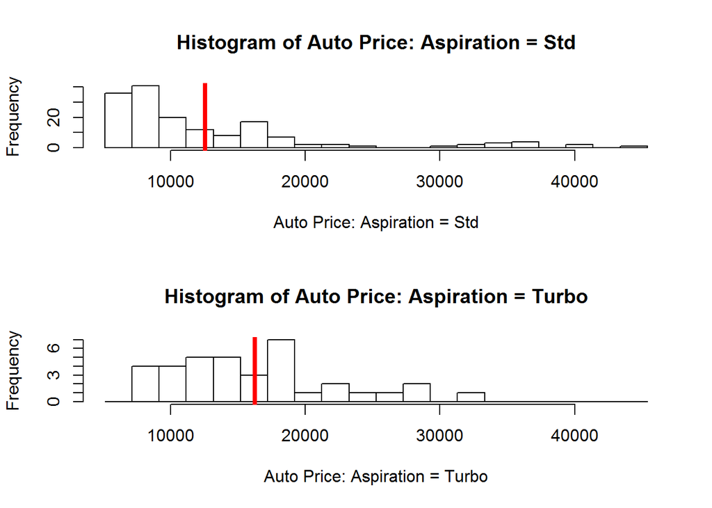

```r
auto.std.price = auto[auto$aspiration=="std",]$price
auto.turbo.price = auto[auto$aspiration == "turbo",]$price
plot.t(auto.std.price, auto.turbo.price, cols = c("Auto Price: Aspiration = Std","Auto Price: Aspiration = Turbo"))
```

```r
t.test(auto.std.price, auto.turbo.price)
```

```
##
##  Welch Two Sample t-test
##
## data:  auto.std.price and auto.turbo.price
## t = -3.0181, df = 66.866, p-value = 0.003598
## alternative hypothesis: true difference in means is not equal to 0
## 95 percent confidence interval:
##  -6126.462 -1248.683
## sample estimates:
## mean of x mean of y
##  12567.23  16254.81
```

The p-value is 0.0036 which is smaller than significance level of 0.05. With this we can reject the null hypothesis that the mean value of the price is same for turbo and standard vehicle. This test shows that mean value of the turbo and standard vehicles are different

#### Student-t test measuring the difference in mean values of prices based on Driver wheel type

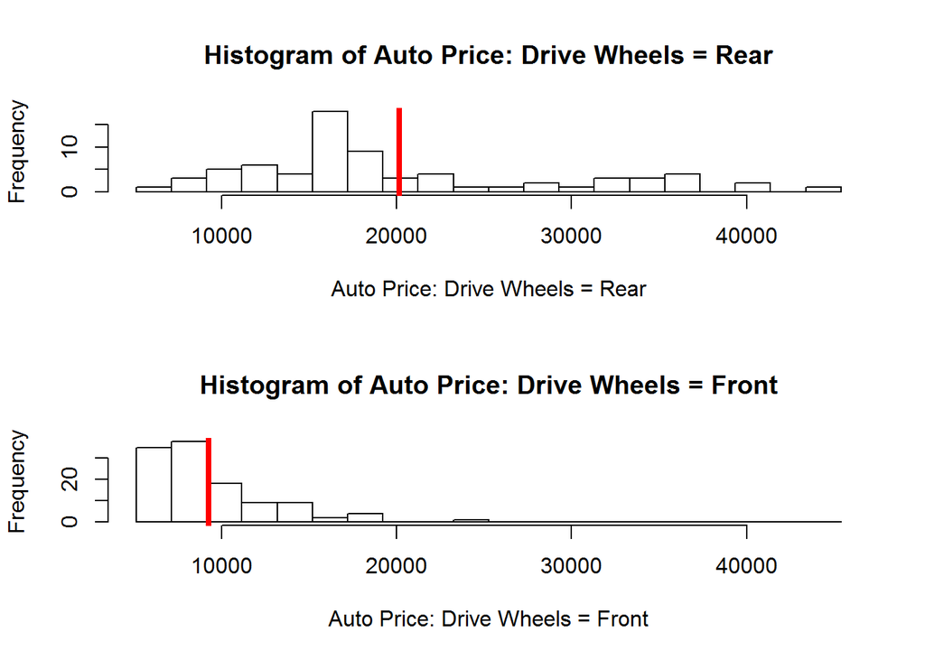

```r
auto.rwd.price = auto[auto$drive.wheels=="rwd",]$price
auto.fwd.price = auto[auto$drive.wheels == "fwd",]$price
plot.t(auto.rwd.price, auto.fwd.price, cols = c("Auto Price: Drive Wheels = Rear","Auto Price: Drive Wheels = Front"))
```

```r
t.test(auto.rwd.price, auto.fwd.price)
```

```
##
##  Welch Two Sample t-test
##
## data:  auto.rwd.price and auto.fwd.price
## t = 9.6134, df = 81.715, p-value = 4.495e-15
## alternative hypothesis: true difference in means is not equal to 0
## 95 percent confidence interval:
##   8643.096 13153.816
## sample estimates:
## mean of x mean of y
## 20137.197  9238.741
```

The p-value is 4.49 e-15 which is way smaller than significance level of 0.05. With this we can reject the null hypothesis that the mean value of the price is same for Front wheel drive and Rear wheel drive vehicle. This test shows that mean value of the FWD and RWD vehicles are different.

# Q3: Analysis of Variance

- Apply ANOVA to the auto price data to compare the price (or log price if closer to a Normal distribution) of autos stratified by number of doors, and body style - two sets of tests.
- Graphically explore the differences between the price conditioned by the categories of each variable. Hint, make sure you have enough data for each category.
- Use standard ANOVA and Tukey ANOVA to test the differences of these groups.

#### Running Analysis of Variance and Tukey’s Honest Significance Difference test

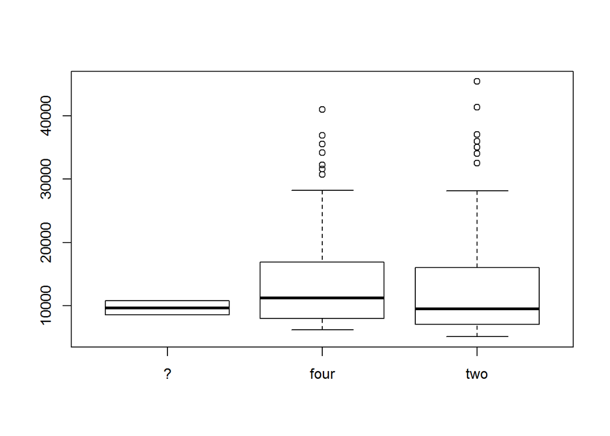

```r
#Boxplot
boxplot(price~num.of.doors, data = auto)
```

```r
auto.door.aov = aov(price ~ as.factor(num.of.doors), data = auto)
summary(auto.door.aov)
```

```
##                          Df    Sum Sq  Mean Sq F value Pr(>F)
## as.factor(num.of.doors)   2 5.289e+07 26447169   0.405  0.668
## Residuals               192 1.254e+10 65305051
```

```r
print(auto.door.aov)
```

```
## Call:
##    aov(formula = price ~ as.factor(num.of.doors), data = auto)
##
## Terms:
##                 as.factor(num.of.doors)   Residuals
## Sum of Squares                 52894338 12538569849
## Deg. of Freedom                       2         192
##
## Residual standard error: 8081.154
## Estimated effects may be unbalanced
```

- Since we did not eliminate entries which have “?” there are three categories shown for number of doors.
- p-value is 0.668; hence we cannot reject the null hypotheses that the price in categories are similar.
- In the upcoming section, we will remove the ‘?’ and just compare 2 doors and 4 door model

```r
tukey.door.anova = TukeyHSD(auto.door.aov)
tukey.door.anova
```

```
##   Tukey multiple comparisons of means
##     95% family-wise confidence level
##
## Fit: aov(formula = price ~ as.factor(num.of.doors), data = auto)
##
## $`as.factor(num.of.doors)`
##               diff        lwr       upr     p adj
## four-?   3927.3036  -9689.897 17544.504 0.7747110
## two-?    3167.7469 -10495.092 16830.586 0.8478074
## two-four -759.5567  -3543.668  2024.554 0.7957495
```

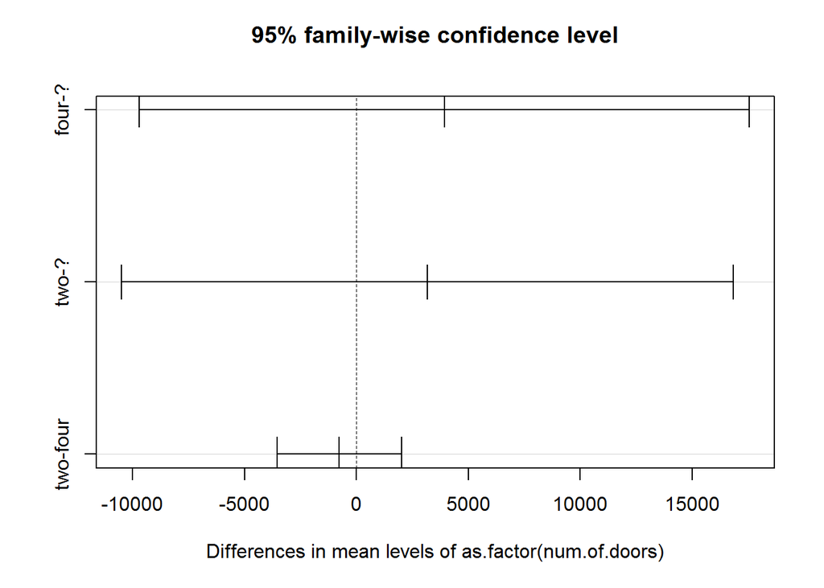

```r
plot(tukey.door.anova)
```

- In the pair wise comparison as well, the p-values are high hence there are no significant differences in price between the categories.

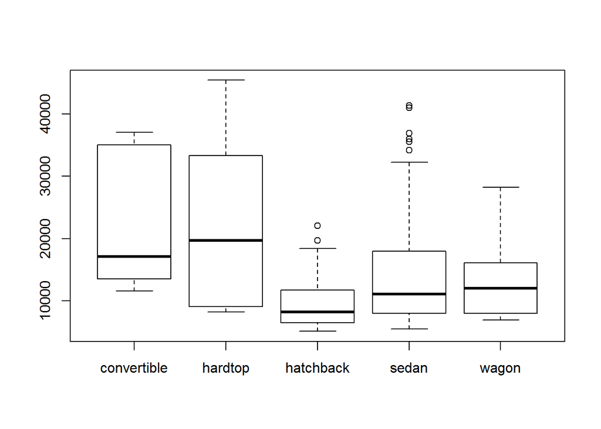

```r
boxplot(price~body.style, data = auto)
```

```r
auto.body.aov = aov(price ~ as.factor(body.style), data = auto)
summary(auto.body.aov)
```

```
##                        Df    Sum Sq   Mean Sq F value   Pr(>F)
## as.factor(body.style)   4 2.007e+09 501661379   9.005 1.11e-06 ***
## Residuals             190 1.058e+10  55709572
## ---
## Signif. codes:  0 '***' 0.001 '**' 0.01 '*' 0.05 '.' 0.1 ' ' 1
```

```r
print(auto.body.aov)
```

```
## Call:
##    aov(formula = price ~ as.factor(body.style), data = auto)
##
## Terms:
##                 as.factor(body.style)   Residuals
## Sum of Squares             2006645518 10584818669
## Deg. of Freedom                     4         190
##
## Residual standard error: 7463.885
## Estimated effects may be unbalanced
```

- The Analysis of Variance based on body.style gives a p-value of < 1.11e-06, hence we can reject the null-hypotheses and specify that there are significant differences in price dependent on the body style

```r
tukey.body.anova = TukeyHSD(auto.body.aov)
tukey.body.anova
```

```
##   Tukey multiple comparisons of means
##     95% family-wise confidence level
##
## Fit: aov(formula = price ~ as.factor(body.style), data = auto)
##
## $`as.factor(body.style)`
##                             diff        lwr          upr     p adj
## hardtop-convertible      318.000 -10783.871 11419.871137 0.9999912
## hatchback-convertible -12126.516 -20909.284 -3343.747520 0.0017866
## sedan-convertible      -7430.745 -16086.665  1225.175259 0.1297690
## wagon-convertible      -9390.333 -18773.127    -7.539706 0.0497064
## hatchback-hardtop     -12444.516 -20160.062 -4728.969444 0.0001460
## sedan-hardtop          -7748.745 -15319.583  -177.906765 0.0419991
## wagon-hardtop          -9708.333 -18100.559 -1316.107586 0.0143955
## sedan-hatchback         4695.771   1348.673  8042.869032 0.0014261
## wagon-hatchback         2736.183  -2194.835  7667.199697 0.5454424
## wagon-sedan            -1959.589  -6660.957  2741.779260 0.7807015
```

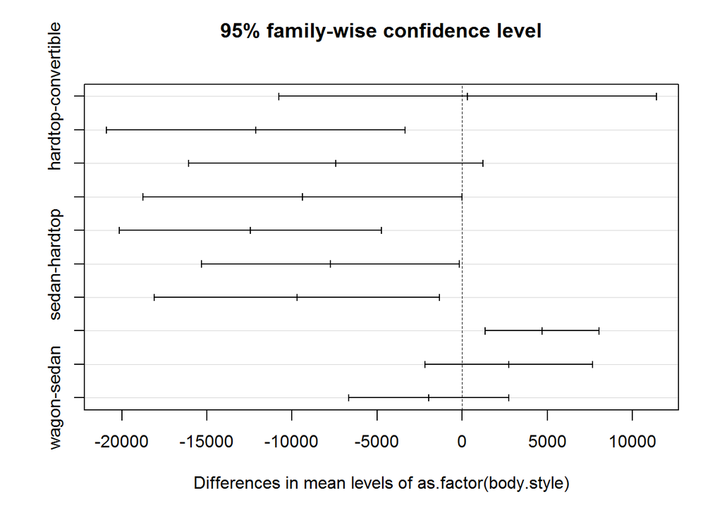

```r
plot(tukey.body.anova)
```

- Some p-values are low indicating significant differences in the price dependent on the body style Following pairs have significanly different prices
- Hatchback and Convertible
- Wagon and Convertible
- Hatchback and Hardtop
- Sedan and Hardtop
- Wagon and Hardtop
- Sedan and Hatchback.

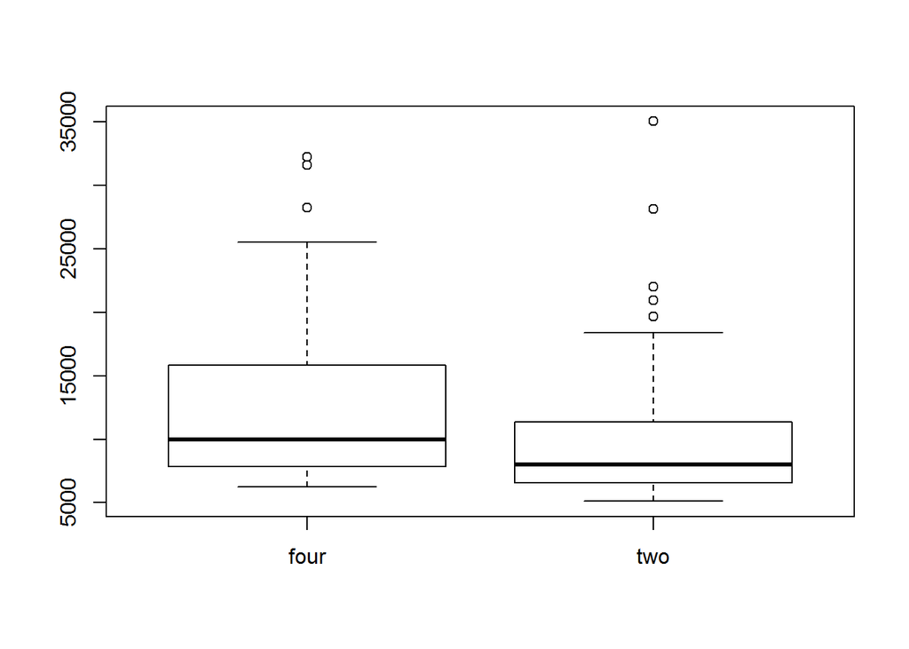

```r
#Reading the data
auto = read.csv("Automobile price data _Raw_.csv", header = TRUE, stringsAsFactors = FALSE, na.strings = "?")
numcols = c("price","bore","stroke","horsepower","peak.rpm")
auto[, numcols] <- lapply(auto[, numcols], as.numeric)

# Removing rows with NAs
auto = auto[complete.cases(auto),]

boxplot(price~num.of.doors, data = auto)
```

```r
auto.door.aov = aov(price ~ as.factor(num.of.doors), data = auto)
summary(auto.door.aov)
```

```
##                          Df    Sum Sq   Mean Sq F value Pr(>F)
## as.factor(num.of.doors)   1 1.435e+08 143528709    4.24 0.0411 *
## Residuals               157 5.315e+09  33855056
## ---
## Signif. codes:  0 '***' 0.001 '**' 0.01 '*' 0.05 '.' 0.1 ' ' 1
```

```r
print(auto.door.aov)
```

```
## Call:
##    aov(formula = price ~ as.factor(num.of.doors), data = auto)
##
## Terms:
##                 as.factor(num.of.doors)  Residuals
## Sum of Squares                143528709 5315243857
## Deg. of Freedom                       1        157
##
## Residual standard error: 5818.51
## Estimated effects may be unbalanced
```

```r
tukey.door.anova = TukeyHSD(auto.door.aov)
tukey.door.anova
```

```
##   Tukey multiple comparisons of means
##     95% family-wise confidence level
##
## Fit: aov(formula = price ~ as.factor(num.of.doors), data = auto)
##
## $`as.factor(num.of.doors)`
##               diff       lwr       upr     p adj
## two-four -1937.386 -3795.906 -78.86603 0.0411457
```

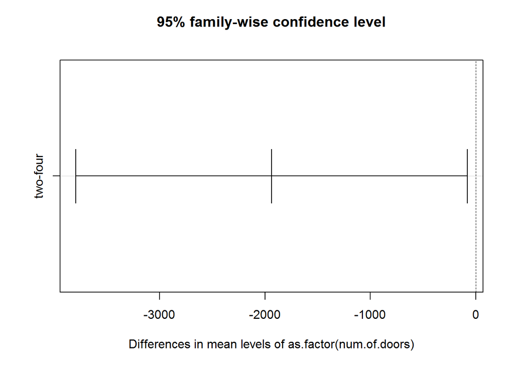

```r
plot(tukey.door.anova)
```

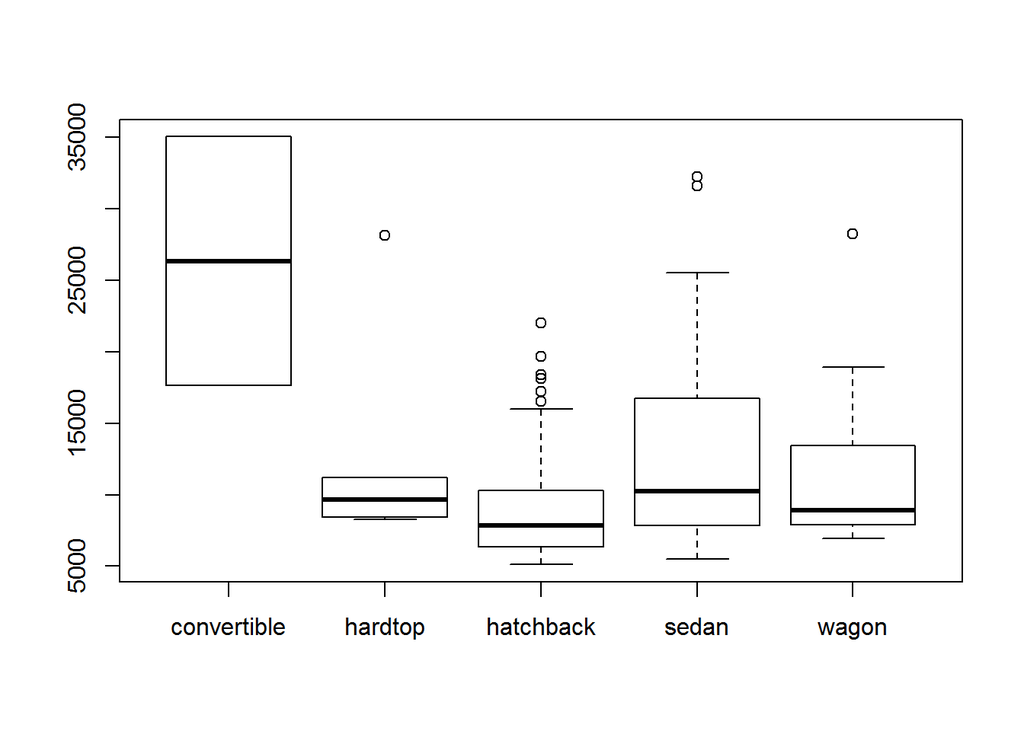

```r
boxplot(price~body.style, data = auto)
```

```r
auto.body.aov = aov(price ~ as.factor(body.style), data = auto)
summary(auto.body.aov)
```

```
##                        Df    Sum Sq   Mean Sq F value  Pr(>F)
## as.factor(body.style)   4 8.348e+08 208696267   6.951 3.6e-05 ***
## Residuals             154 4.624e+09  30025893
## ---
## Signif. codes:  0 '***' 0.001 '**' 0.01 '*' 0.05 '.' 0.1 ' ' 1
```

```r
print(auto.body.aov)
```

```
## Call:
##    aov(formula = price ~ as.factor(body.style), data = auto)
##
## Terms:
##                 as.factor(body.style)  Residuals
## Sum of Squares              834785067 4623987498
## Deg. of Freedom                     4        154
##
## Residual standard error: 5479.589
## Estimated effects may be unbalanced
```

```r
tukey.body.anova = TukeyHSD(auto.body.aov)
tukey.body.anova
```

```
##   Tukey multiple comparisons of means
##     95% family-wise confidence level
##
## Fit: aov(formula = price ~ as.factor(body.style), data = auto)
##
## $`as.factor(body.style)`
##                              diff         lwr        upr     p adj
## hardtop-convertible   -13220.1000 -25875.1445  -565.0555 0.0358309
## hatchback-convertible -17142.3393 -28027.1189 -6257.5596 0.0002393
## sedan-convertible     -13803.8797 -24633.8839 -2973.8756 0.0051074
## wagon-convertible     -15011.0882 -26318.2082 -3703.9683 0.0030975
## hatchback-hardtop      -3922.2393 -10982.1719  3137.6934 0.5423595
## sedan-hardtop           -583.7797  -7558.9651  6391.4056 0.9993627
## wagon-hardtop          -1790.9882  -9486.1284  5904.1519 0.9678052
## sedan-hatchback         3338.4595    696.2091  5980.7100 0.0056587
## wagon-hatchback         2131.2511  -2057.2402  6319.7423 0.6256723
## wagon-sedan            -1207.2085  -5251.2189  2836.8019 0.9228635
```

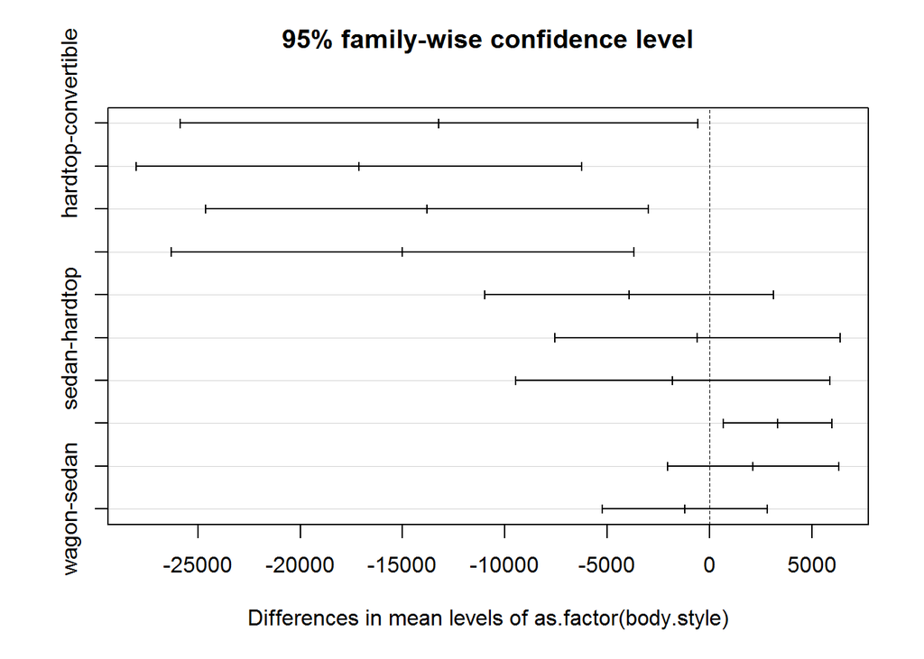

```r
plot(tukey.body.anova)
```